# Pipeline de pré-processamento e PCA em R

LendingClub, treino da classificação (2007-06 a 2011-12)

# 1 Objetivo

As transformações que aprendem com os dados (imputação, padronização, redução de dimensionalidade, etc.) têm de ser ajustadas **só no treino** de cada *fold* da validação cruzada e aplicadas à validação **sem novo ajuste**. Em Python, isso é feito pelo pipeline de `src/lending/preprocessing.py`. Aqui faz-se o equivalente em R com o pacote `recipes`, onde:

| `recipes` | scikit-learn | O que faz |
| --- | --- | --- |
| `recipe()` + `step_*()` | `Pipeline([...])` | Define os passos, sem olhar para os dados |
| `prep(receita, training = treino)` | `fit(treino)` | Aprende os parâmetros (medianas, médias, desvios-padrão, eixos do PCA) **só com o treino** |
| `bake(receita_preparada, new_data = validação)` | `transform(validação)` | Aplica os parâmetros aprendidos, **sem os voltar a aprender** |

Há dois tipos de passos:

- **Fixos** (não aprendem nada com os dados): o logaritmo. Dão o mesmo resultado em qualquer conjunto.
- **Aprendidos**: a imputação pela mediana, a padronização e o PCA. São estes que têm de ser ajustados só no treino de cada *fold*; se a validação entrasse no ajuste, a avaliação ficaria otimista (fuga de informação).

O documento tem duas partes:

1. o pipeline dentro da **validação temporal**, com as provas de que o ajuste só usa o treino;
2. um **PCA** em R (redução de dimensionalidade linear), com o mesmo pipeline, comparado com o PCA feito em Python na análise exploratória (`notebooks/02_eda.ipynb`).

**Dados:** só o treino da classificação (empréstimos de 36 meses de 2007-06 a 2011-12), exportado por `notebooks/02b_dados_testes_hipoteses.ipynb` sem alterar valores. O teste final (2015) nunca é usado.

# 2 Dados

Usam-se as mesmas 14 colunas numéricas do PCA da classificação na análise exploratória, para se poder comparar o resultado com o do Python.

```r
dados <- fread("data/processed/hipoteses/pipeline_classificacao.csv")
dados[, ano := year(issue_d)]

COLUNAS <- c("loan_amnt", "annual_inc", "dti", "fico_range_low", "revol_util", "revol_bal",
             "open_acc", "total_acc", "inq_last_6mths", "delinq_2yrs", "pub_rec",
             "int_rate", "installment", "emp_length")
# Colunas com cauda longa, em escala log (as mesmas do PCA da análise exploratória)
COLUNAS_LOG <- c("annual_inc", "revol_bal")

X <- as.data.frame(dados[, ..COLUNAS])
cat(nrow(X), "empréstimos x", ncol(X), "colunas\n")
```

```
31522 empréstimos x 14 colunas
```

```r
dados[, .N, keyby = ano]
```

```
Key: <ano>
     ano     N
   <int> <int>
1:  2007   603
2:  2008  2388
3:  2009  5280
4:  2010  9153
5:  2011 14098
```

```r
# Valores em falta por coluna: são tratados pela imputação do pipeline
faltas <- colSums(is.na(X))
faltas[faltas > 0]
```

```
    annual_inc     revol_util       open_acc      total_acc inq_last_6mths
             4             86             29             29             29
   delinq_2yrs        pub_rec     emp_length
            29             29            835
```

# 3 A receita (o pipeline)

Os mesmos passos do pré-processamento do PCA em Python (`src/lending/dimred.py`):

1. `step_log`: $\log_{10}(1 + x)$ nas colunas com cauda longa (**fixo**);
2. `step_impute_median`: os valores em falta passam à mediana **do treino** (**aprendido**);
3. `step_normalize`: subtrai a média e divide pelo desvio-padrão **do treino** (**aprendido**). Sem este passo, as variáveis com números grandes (ex.: o montante) dominariam as distâncias e o PCA só pela escala.

```r
receita <- recipe(~ ., data = X) |>
  step_log(all_of(COLUNAS_LOG), base = 10, offset = 1) |>
  step_impute_median(all_numeric_predictors()) |>
  step_normalize(all_numeric_predictors())
receita
```

```
── Recipe ──────────────────────────────────────────────────────────────────────
```

```
── Inputs
```

```
Number of variables by role
```

```
predictor: 14
```

```
── Operations
```

```
• Log transformation on: all_of(COLUNAS_LOG)
```

```
• Median imputation for: all_numeric_predictors()
```

```
• Centering and scaling for: all_numeric_predictors()
```

A receita ainda não aprendeu nada: só descreve os passos.

# 4 Validação temporal com o pipeline

Os *folds* são os mesmos da classificação em Python (`ExpandingWindowSplit("Y", min_train_periods = 2)` no `notebooks/01c_pipeline.ipynb`): janela expansível por ano, em que cada *fold* treina com todos os anos anteriores e valida no ano seguinte. Os empréstimos do mesmo ano ficam sempre juntos.

```r
anos_validacao <- 2009:2011
folds <- lapply(anos_validacao, function(a) list(
  ano = a,
  treino = which(dados$ano < a),
  validacao = which(dados$ano == a)
))
data.frame(
  fold = seq_along(folds),
  treino = sapply(folds, function(f) paste(min(dados$ano[f$treino]), "a", max(dados$ano[f$treino]))),
  validacao = sapply(folds, function(f) f$ano),
  linhas_treino = sapply(folds, function(f) length(f$treino)),
  linhas_validacao = sapply(folds, function(f) length(f$validacao))
)
```

```
  fold      treino validacao linhas_treino linhas_validacao
1    1 2007 a 2008      2009          2991             5280
2    2 2007 a 2009      2010          8271             9153
3    3 2007 a 2010      2011         17424            14098
```

Em cada *fold*, a receita é preparada (`prep`) **só com o treino** e aplicada (`bake`) ao treino e à validação. Guardam-se alguns números para provar que o ajuste não viu a validação, usando o `dti` como exemplo.

```r
# Valor aprendido para uma coluna num passo da receita preparada
aprendido <- function(preparada, passo, coluna, estatistica = NULL) {
  t <- tidy(preparada, number = passo)
  if (!is.null(estatistica)) t <- t[t$statistic == estatistica, ]
  t$value[t$terms == coluna]
}

resultados <- lapply(folds, function(f) {
  treino <- X[f$treino, ]
  validacao <- X[f$validacao, ]

  preparada <- prep(receita, training = treino)        # fit: só o treino
  treino_t <- bake(preparada, new_data = NULL)          # o próprio treino transformado
  validacao_t <- bake(preparada, new_data = validacao)  # transform: sem novo ajuste

  # Prova 1: preparar outra vez só com o treino dá exatamente a mesma transformação
  repetida <- bake(prep(receita, training = treino), new_data = validacao)
  # Contraste: se a validação entrasse no ajuste (fuga de informação), o resultado mudava
  com_fuga <- bake(prep(receita, training = rbind(treino, validacao)), new_data = validacao)

  data.frame(
    fold = f$ano,
    mediana_aprendida = aprendido(preparada, 2, "dti"),
    mediana_treino = median(treino$dti, na.rm = TRUE),
    mediana_validacao = median(validacao$dti, na.rm = TRUE),
    media_aprendida = aprendido(preparada, 3, "dti", "mean"),
    media_dti_t_treino = mean(treino_t$dti),
    media_dti_t_validacao = mean(validacao_t$dti),
    repeticao_igual = isTRUE(all.equal(as.data.frame(repetida), as.data.frame(validacao_t))),
    diferenca_com_fuga = max(abs(as.matrix(com_fuga) - as.matrix(validacao_t))),
    faltas_depois = sum(is.na(validacao_t))
  )
})
provas <- do.call(rbind, resultados)
format(provas, digits = 3)
```

```
  fold mediana_aprendida mediana_treino mediana_validacao media_aprendida
1 2009              12.4           12.4              12.6            12.7
2 2010              12.6           12.6              13.0            12.6
3 2011              12.8           12.8              13.4            12.7
  media_dti_t_treino media_dti_t_validacao repeticao_igual diferenca_com_fuga
1          -1.02e-16               -0.0316            TRUE              1.920
2          -9.88e-17                0.0487            TRUE              1.015
3           7.79e-17                0.1121            TRUE              0.853
  faltas_depois
1             0
2             0
3             0
```

**Como ler a tabela:**

- **`mediana_aprendida` = `mediana_treino`**, e é diferente de `mediana_validacao`: a imputação aprendeu a mediana só com o treino do *fold*.
- **`media_aprendida`** é a média do `dti` no treino; depois da padronização, a média é 0 no treino (`media_dti_t_treino`, salvo erros de arredondamento) mas **não** na validação (`media_dti_t_validacao`): a validação foi transformada com os parâmetros do treino e não com os seus.
- **`repeticao_igual` = TRUE**: preparar de novo só com o treino dá exatamente a mesma transformação da validação, ou seja, o resultado não depende da validação.
- **`diferenca_com_fuga` > 0**: se a validação entrasse no `prep`, os valores transformados mudavam. É precisamente o que o pipeline evita.
- **`faltas_depois` = 0**: não ficam valores em falta depois da imputação.

Na Parte 2, o modelo entra no fim deste fluxo: em cada *fold*, receita e modelo são ajustados juntos só no treino (em R, com um `workflow` do `tidymodels`; em Python, com o `Pipeline`), e avaliados na validação.

# 5 PCA em R

O PCA (análise em componentes principais) procura as direções de maior variância dos dados: cada componente é uma combinação linear das variáveis padronizadas, e as componentes são ordenadas pela variância que explicam. É um passo **aprendido** (os eixos dependem dos dados), por isso entra na receita como mais um passo, `step_pca`, a seguir à padronização.

Aqui o PCA é usado como **análise exploratória**, tal como em Python: é ajustado em todo o treino da classificação, para descrever a estrutura dos dados. Se fosse usado como entrada de um modelo, seria preparado dentro de cada *fold*, como os passos anteriores.

```r
receita_pca <- receita |> step_pca(all_numeric_predictors(), num_comp = length(COLUNAS))
pca <- prep(receita_pca, training = X)

variancia <- tidy(pca, number = 4, type = "variance")
var_pct <- variancia$value[variancia$terms == "percent variance"]
var_acum <- variancia$value[variancia$terms == "cumulative percent variance"]
n_80 <- which(var_acum >= 80)[1]

data.frame(componente = paste0("PC", seq_along(var_pct)),
           variancia_pct = round(var_pct, 2),
           acumulada_pct = round(var_acum, 2))[1:8, ]
```

```
  componente variancia_pct acumulada_pct
1        PC1         21.62         21.62
2        PC2         17.54         39.15
3        PC3         11.60         50.75
4        PC4          9.40         60.15
5        PC5          7.59         67.74
6        PC6          7.20         74.94
7        PC7          6.16         81.10
8        PC8          5.88         86.98
```

```r
cat("Componentes para explicar 80% da variância:", n_80, "\n")
```

```
Componentes para explicar 80% da variância: 7
```

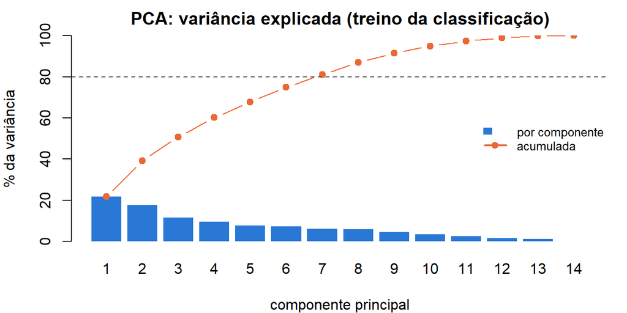

```r
par(mar = c(4, 4, 2, 1))
barras <- barplot(var_pct, names.arg = seq_along(var_pct), col = "#2a78d6", border = NA,
                  ylim = c(0, 100), xlab = "componente principal", ylab = "% da variância",
                  main = "PCA: variância explicada (treino da classificação)")
lines(barras, var_acum, type = "b", pch = 19, col = "#eb6834")
abline(h = 80, lty = 2, col = "#52514e")
legend("right", c("por componente", "acumulada"), fill = c("#2a78d6", NA), border = NA,
       col = c(NA, "#eb6834"), lwd = c(NA, 2), pch = c(NA, 19), bty = "n", cex = 0.8)
```

**O que mede cada componente** (pesos das variáveis nas três primeiras):

```r
pesos <- tidy(pca, number = 4, type = "coef")
pesos <- dcast(as.data.table(pesos)[component %in% c("PC1", "PC2", "PC3")],
               terms ~ component, value.var = "value")
pesos[order(-abs(PC1))][, lapply(.SD, function(v) if (is.numeric(v)) round(v, 3) else v)]
```

```
             terms    PC1    PC2    PC3
            <char>  <num>  <num>  <num>
 1:    installment  0.435  0.092  0.449
 2:      loan_amnt  0.430  0.134  0.440
 3:     annual_inc  0.371  0.154  0.089
 4:      total_acc  0.369  0.170 -0.406
 5:      revol_bal  0.351 -0.126 -0.156
 6:       open_acc  0.345  0.086 -0.456
 7:            dti  0.182 -0.187 -0.375
 8:     revol_util  0.164 -0.462  0.033
 9:     emp_length  0.158  0.104 -0.092
10:       int_rate  0.140 -0.512  0.194
11: fico_range_low -0.056  0.577  0.018
12: inq_last_6mths  0.047 -0.118 -0.091
13:    delinq_2yrs  0.008 -0.114 -0.024
14:        pub_rec -0.002 -0.127 -0.044
```

## 5.1 Comparação com o PCA em Python

Os valores de referência são os do PCA da classificação no `notebooks/02_eda.ipynb` (`DimensionalityReducer.explained_variance()`), com as mesmas colunas e os mesmos passos.

```r
python_pct <- c(21.62, 17.54, 11.60, 9.40, 7.59, 7.20, 6.16, 5.88)
comparacao <- data.frame(componente = paste0("PC", 1:8),
                         R = round(var_pct[1:8], 2),
                         Python = python_pct)
comparacao$diferenca <- round(comparacao$R - comparacao$Python, 2)
comparacao
```

```
  componente     R Python diferenca
1        PC1 21.62  21.62         0
2        PC2 17.54  17.54         0
3        PC3 11.60  11.60         0
4        PC4  9.40   9.40         0
5        PC5  7.59   7.59         0
6        PC6  7.20   7.20         0
7        PC7  6.16   6.16         0
8        PC8  5.88   5.88         0
```

```r
stopifnot(all(abs(comparacao$diferenca) < 0.01))
```

**Os resultados são iguais nas duas linguagens:** a mesma variância explicada por componente e as mesmas 7 componentes para 80%. Os pesos também coincidem (por exemplo, 0,430 para o `loan_amnt` na PC1). Pequenos pormenores de implementação não mudam o resultado:

- o Python divide o desvio-padrão por $n$ e o R por $n - 1$, mas esse fator é igual em todas as colunas e não altera as proporções da variância;
- o sinal de uma componente é arbitrário (multiplicar uma componente por $-1$ dá a mesma direção), por isso os pesos podem aparecer com o sinal trocado entre implementações.

**Interpretação** (a mesma da análise exploratória): a informação está espalhada por muitas direções. São precisas 7 das 14 componentes para explicar 80% da variância, e a primeira explica só 21.6%. A PC1 resume o **volume do crédito** (montante, prestação, rendimento, número de contas e saldo rotativo pesam todos no mesmo sentido), e a PC2 opõe o FICO à taxa de juro e à utilização do crédito rotativo, ou seja, mede a **qualidade do crédito**. Não há poucas direções que resumam bem os dados, o que sugere manter as variáveis originais nos modelos em vez de as substituir por componentes.

# 6 Reprodutibilidade

Para gerar este relatório (a partir da pasta do projeto, depois de correr `notebooks/02b_dados_testes_hipoteses.ipynb`):

```
Rscript -e "rmarkdown::render('R/pipeline_pca.Rmd', output_dir = 'reports')"
```

Precisa dos pacotes `rmarkdown`, `knitr`, `data.table` e `recipes`, e do pandoc. O PCA e a imputação não têm componentes aleatórias, por isso os resultados são sempre os mesmos.